# Final Project

Thomas Grover

2024-12-2

## Task 1

Loading necessary packages.

```r
library(tidyverse)
library(knitr)
library(dplyr)
```

Reading in the house data.

```r
house_data <- read.csv("https://www4.stat.ncsu.edu/~online/ST308/Data/tmgrover_house.csv")
```

Creating the modified tibble as specified. Starting by using `filter()`to get rid of any houses with `neighborhood = "StoneBr"` and so we only include houses with garages built after 1958. Then I added a new variable that divides the sale price by 100,000 so that the prices are easier to look at. Lastly, using `select()` to remove the `OverallQual` and `BsmtFinType2` variables, and the `kable()` function in the `knitr` package to display a section of the new tibble.

```r
new_house_data <- house_data %>%
  filter(Neighborhood != "StoneBr" & GarageYrBlt > 1958) %>%
  mutate(SalePriceInHundredThousands = SalePrice / 100000) %>%
  select(-OverallQual, -BsmtFinType2)

kable(new_house_data[1:10, 1:6])
```

| SalePrice | YrSold | YearBuilt | GarageArea | GarageYrBlt | WoodDeckSF |
| --- | --- | --- | --- | --- | --- |
| 208500 | 2008 | 2003 | 548 | 2003 | 0 |
| 181500 | 2007 | 1976 | 460 | 1976 | 298 |
| 140000 | 2006 | 1915 | 642 | 1998 | 0 |
| 250000 | 2008 | 2000 | 836 | 2000 | 192 |
| 143000 | 2009 | 1993 | 480 | 1993 | 40 |
| 307000 | 2007 | 2004 | 636 | 2004 | 255 |
| 129500 | 2008 | 1965 | 384 | 1965 | 0 |
| 345000 | 2006 | 2005 | 736 | 2005 | 147 |
| 144000 | 2008 | 1962 | 352 | 1962 | 140 |
| 132000 | 2007 | 1929 | 576 | 1991 | 48 |

Here I generate some summary statistics of three specified variables at every level of the `Condition2` variable. I use the `kable()` function again for a nice display. The chaining basically goes through each level of `Condition2`, generating the stats for the specified variables one level at a time. In the data set there are only 2 levels of the `Condition2`, so the kable function yields a table with 2 rows.

```r
stats <- new_house_data %>%
  group_by(Condition2) %>%
  summarize(
    m_SalePrice = mean(SalePrice),
    sd_SalePrice = sd(SalePrice),
    q1_SalePrice = quantile(SalePrice, 0.25),
    q3_SalePrice = quantile(SalePrice, 0.75),
    m_YrSold = mean(YrSold),
    sd_YrSold = sd(YrSold),
    q1_YrSold = quantile(YrSold, 0.25),
    q3_YrSold = quantile(YrSold, 0.75),
    m_YearBuilt = mean(YearBuilt),
    sd_YearBuilt = sd(YearBuilt),
    q1_YearBuilt = quantile(YearBuilt, 0.25),
    q3_YearBuilt = quantile(YearBuilt, 0.75)
  )

kable(stats)
```

| Condition2 | m_SalePrice | sd_SalePrice | q1_SalePrice | q3_SalePrice | m_YrSold | sd_YrSold | q1_YrSold | q3_YrSold | m_YearBuilt | sd_YearBuilt | q1_YearBuilt | q3_YearBuilt |
| --- | --- | --- | --- | --- | --- | --- | --- | --- | --- | --- | --- | --- |
| Norm | 196620.1 | 76997.24 | 144000 | 230000.0 | 2007.849 | 1.349138 | 2007.00 | 2009.00 | 1982.414 | 24.9042 | 1968.00 | 2003.00 |
| Other | 129317.5 | 28758.94 | 125500 | 139226.2 | 2008.000 | 1.414214 | 2007.25 | 2008.75 | 1933.333 | 26.9790 | 1912.75 | 1948.75 |

Next I create a scatter plot with `Sale Price` on the Y-axis and `YrSold` on the X-axis. I used the `color = Condition2` option to color the points by the `Condition2` level. I also utilized the `+` operator. First to add the points with the `geom_point()` function, and then to customize the graph with a title, and some nicer looking axis labels using `labs()`.

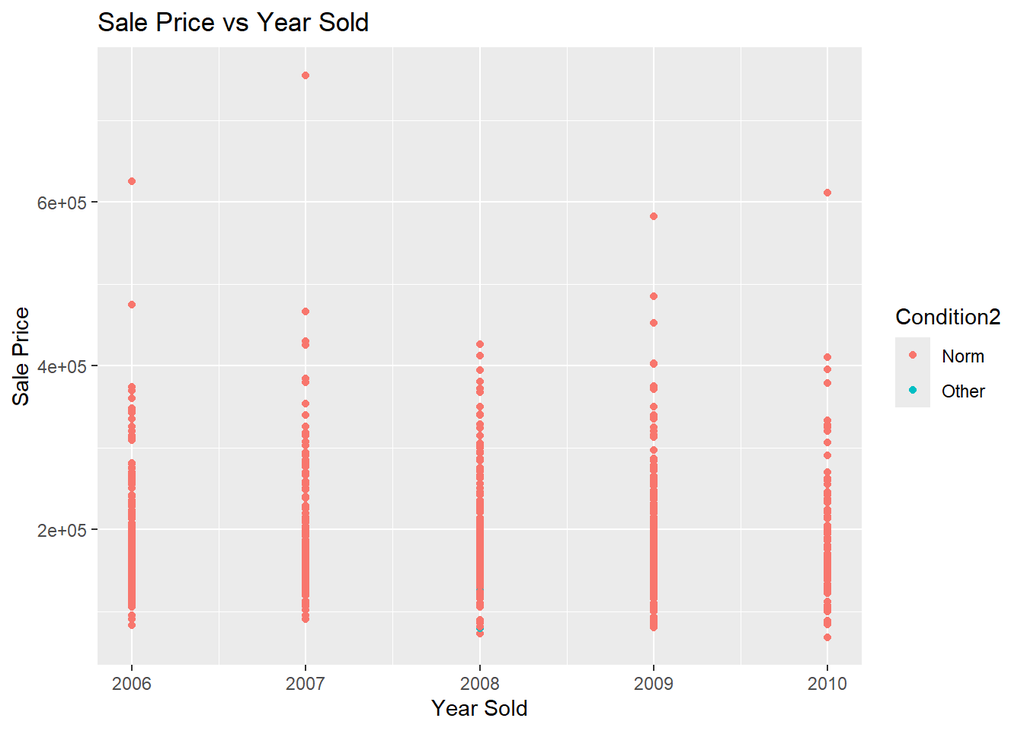

```r
ggplot(new_house_data, aes(x = YrSold, y = SalePrice, color = Condition2)) +
  geom_point() +
  labs(title = "Sale Price vs Year Sold", x = "Year Sold", y = "Sale Price")
```

Here I am fitting a multiple linear regression model, with `SalePrice` as the response, and `YrSold` and `YearBuilt` as predictors. Calling the `summary()` of the model to check if either predictor is significant.

```r
model <- lm(SalePrice ~ YrSold + YearBuilt, data = new_house_data)
summary(model)
```

```
##
## Call:
## lm(formula = SalePrice ~ YrSold + YearBuilt, data = new_house_data)
##
## Residuals:
##     Min      1Q  Median      3Q     Max
## -102618  -42203  -15120   23944  541829
##
## Coefficients:
##               Estimate Std. Error t value Pr(>|t|)
## (Intercept) -2.790e+06  3.669e+06  -0.760    0.447
## YrSold       7.380e+01  1.819e+03   0.041    0.968
## YearBuilt    1.432e+03  9.709e+01  14.748   <2e-16 ***
## ---
## Signif. codes:  0 '***' 0.001 '**' 0.01 '*' 0.05 '.' 0.1 ' ' 1
##
## Residual standard error: 68010 on 769 degrees of freedom
## Multiple R-squared:  0.221,  Adjusted R-squared:  0.219
## F-statistic: 109.1 on 2 and 769 DF,  p-value: < 2.2e-16
```

When looking at the summary, we can see the `Pr(>|t|)` value for the `YearBuilt` variable is extremely small. Thus the estimate for the parameter the model gives is actually significant for `YearBuilt`

Using the model to make a prediction of a sale price for a house built in 2011 and sold in 2015.

```r
prediction1 <- predict(model, newdata = data.frame(YrSold = 2015, YearBuilt = 2011))
prediction1
```

```
##        1
## 238103.4
```

Using the model to make a prediction of a sale price for a house built in 2004 and sold in 2012.

```r
prediction2 <- predict(model, newdata = data.frame(YrSold = 2012, YearBuilt = 2004))
prediction2
```

```
##        1
## 227858.7
```

## Task 2

The data set I will be using has variables about different wines. I found it at this link “https://archive.ics.uci.edu/dataset/186/wine+quality” and it is of interest because for one I don’t really know much about what separates different wines, and for two it was one of the first ones on the website to actually catch my eye. It actually is cool though how the different chemical properties of wine can play a role in the quality and flavor of it. It kind of reminds me of a scene in Breaking Bad where a chemist is trying to perfect coffee.

#### Questions of Interest

1. Is there a relationship between pH and wine quality?
2. What is the spread of the quality variable?

Reading in the data.

```r
wine_data <- read.csv("https://archive.ics.uci.edu/ml/machine-learning-databases/wine-quality/winequality-red.csv", sep=";")
```

Creating a function that takes in a data frame, some specification of columns within that data frame with the default value being the entire data set, and with a grouping option with a default value of `NULL`. The data set I have used for my previous analysis is strictly numerical, meaning there are no grouping nor categorical variable. So my function is able to calculate the summary statistics by using `sapply()` to iterate through the columns of the inputted data frame, and by using an embedded function to calculate the desired statistics of each column that is coming through. Because of the nature of how the data is being collected, we need to use the `t()` function, which calls for the transpose of what you put into it when returning the data. And also using the `kable()` function once again as a simple way to output better looking results.

```r
summarize <- function(data, columns = names(data), grouping = NULL) {
  result <- sapply(data[columns], function(col) {
    c(mean = mean(col, na.rm = TRUE),
      variance = var(col, na.rm = TRUE),
      quantile_05 = quantile(col, 0.05, na.rm = TRUE),
      quantile_95 = quantile(col, 0.95, na.rm = TRUE))
  })

  return(kable(t(result)))
}
```

The function can be used to… provide summary statistics of every variable in the `wine_data` set.

```r
result1 <- summarize(wine_data)
result1
```

|  | mean | variance | quantile_05.5% | quantile_95.95% |
| --- | --- | --- | --- | --- |
| fixed.acidity | 8.3196373 | 3.0314164 | 6.100000 | 11.8000 |
| volatile.acidity | 0.5278205 | 0.0320624 | 0.270000 | 0.8400 |
| citric.acid | 0.2709756 | 0.0379475 | 0.000000 | 0.6000 |
| residual.sugar | 2.5388055 | 1.9878971 | 1.590000 | 5.1000 |
| chlorides | 0.0874665 | 0.0022151 | 0.054000 | 0.1261 |
| free.sulfur.dioxide | 15.8749218 | 109.4148838 | 4.000000 | 35.0000 |
| total.sulfur.dioxide | 46.4677924 | 1082.1023725 | 11.000000 | 112.1000 |
| density | 0.9967467 | 0.0000036 | 0.993598 | 1.0000 |
| pH | 3.3111132 | 0.0238352 | 3.060000 | 3.5700 |
| sulphates | 0.6581488 | 0.0287326 | 0.470000 | 0.9300 |
| alcohol | 10.4229831 | 1.1356474 | 9.200000 | 12.5000 |
| quality | 5.6360225 | 0.6521684 | 5.000000 | 7.0000 |

provide summary stats for a single variable, in this case `chlorides`.

```r
result2 <- summarize(wine_data, "chlorides")
result2
```

|  | mean | variance | quantile_05.5% | quantile_95.95% |
| --- | --- | --- | --- | --- |
| chlorides | 0.0874665 | 0.0022151 | 0.054 | 0.1261 |

and provide summary statistics for a specific list of variables.

```r
result3 <- summarize(wine_data, c("density", "pH", "alcohol"))
result3
```

|  | mean | variance | quantile_05.5% | quantile_95.95% |
| --- | --- | --- | --- | --- |
| density | 0.9967467 | 0.0000036 | 0.993598 | 1.00 |
| pH | 3.3111132 | 0.0238352 | 3.060000 | 3.57 |
| alcohol | 10.4229831 | 1.1356474 | 9.200000 | 12.50 |